# Analysis of HAR Dataset

## 1. Data Cleaning

```r
library(caret)
library(doMC)
registerDoMC(cores = 8)
har = read.csv("pml-training.csv", as.is=T)
```

By using the str function to examing the data, I found there are many variable with lots of NAs or empty string. So I am going to clean these variables

```r
check_NA_percent = function(x) mean(is.na(x))
## check NA percent bigger than 95%
almost_nas_index = apply(har, 2, check_NA_percent) > 0.95
sum(almost_nas_index)
```

```
## [1] 67
```

```r
## remove those variables
har = har[,!almost_nas_index]
check_empty_percent = function(x) mean(x=="")
## check empty string biggrt than 95%
almost_empty_index = apply(har, 2, check_empty_percent) > 0.95
sum(almost_empty_index)
```

```
## [1] 33
```

```r
## remove those variables
har = har[,!almost_empty_index]
dim(har)
```

```
## [1] 19622    60
```

```r
## remove first seven variable according their meaning
har = har[,-c(1,2,3,4,5,6,7)]
dim(har)
```

```
## [1] 19622    53
```

```r
har$classe = factor(har$classe)
```

Finaly I get a clean dataset with 52 independent varaibles and 1 dependent variable.

## 2. Fitting Models with varies methods

Next, I will use different machine learning techniques to fit the model. first devide the har dataset into a traing dataset(75%) and testing dataset(25%).then in the training dataset create 10 fold cross validation dataset.Finally fit the model using tree(rpart), bagging(treebag), boosting(gbm) and random forest(rf).

```r
## Create training and testing dataset
set.seed(1224)
intrain = createDataPartition(y=har$classe,p=0.75,list=F)
training = har[intrain,]
testing = har[-intrain,]
#rm('har')

## use 10 fold cross validation
fitControl <- trainControl(method = "cv", number = 10,  allowParallel=T)

## tree
fit_tree = train(classe ~ ., training, method='rpart', trControl=fitControl)

## bagging
fit_bag = train(classe ~ ., training, method='treebag', trControl=fitControl)


## gardient boosting
fit_gbm = train(classe ~ ., training, method='gbm', trControl=fitControl)
## random forest
fit_rf = train(classe ~ ., training, method='rf', trControl=fitControl)
```

## 3. predict and comparing the accuracy of these methods

```r
error_rate = function(pred, truth){
    mean(pred!=truth)
}
## tree
pred_tree = predict(fit_tree, testing)
#confusionMatrix(pred_tree,testing$classe)
(error_tree = error_rate(pred_tree, testing$classe))
```

```
## [1] 0.4551387
```

```r
## bag
pred_bag = predict(fit_bag, testing)
#confusionMatrix(pred_bag, testing$classe)
(error_bag = error_rate(pred_bag, testing$classe))
```

```
## [1] 0.007544861
```

```r
## boosting
pred_gbm = predict(fit_gbm, testing)
#confusionMatrix(pred_gbm,testing$classe)
(error_gbm = error_rate(pred_gbm, testing$classe))
```

```
## [1] 0.03405383
```

```r
##
pred_rf = predict(fit_rf, testing)
#confusionMatrix(pred_rf,testing$classe)
(error_rf = error_rate(pred_rf, testing$classe))
```

```
## [1] 0.004690049
```

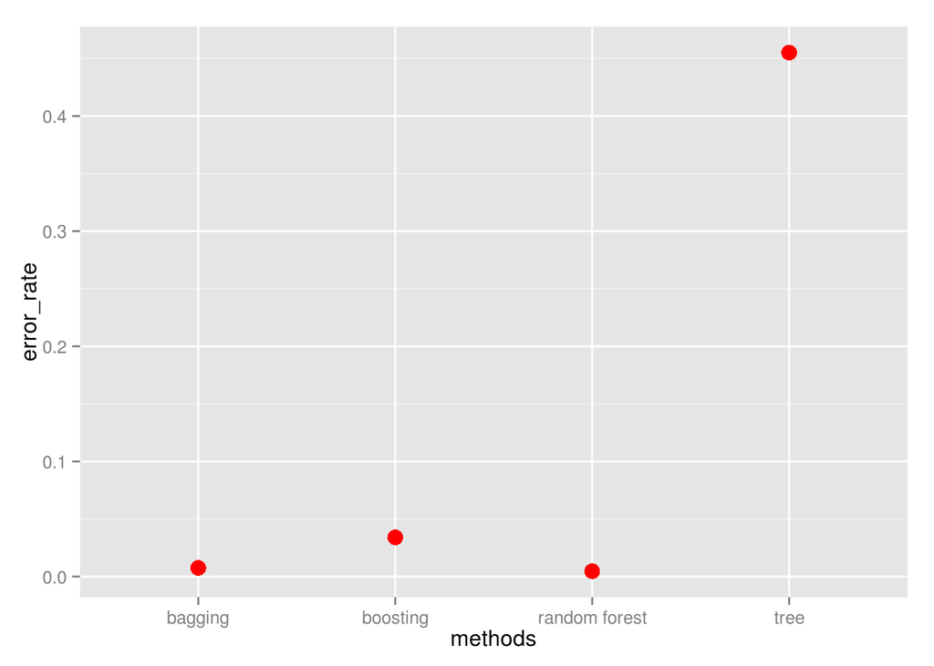

```r
## plot error rate
error_df = data.frame(methods=c("tree","bagging","boosting","random forest"),
                      error_rate=c(error_tree,error_bag,error_gbm,error_rf))
ggplot(data=error_df,aes(x=methods,y=error_rate)) +geom_point(size=4,color="red")
```

Random forests has the lowest out of sample error rate, So I will use random forests to predict the final test set.

## 4. Apply Model to the final test set

```r
har_test = read.csv("pml-testing.csv", as.is=T)
har_test = har_test[,!almost_nas_index]
har_test = har_test[,!almost_empty_index]
har_test = har_test[,-c(1,2,3,4,5,6,7)]
(pred = predict(fit_rf,har_test))
```

```
##  [1] B A B A A E D B A A B C B A E E A B B B
## Levels: A B C D E
```

```r
#pml_write_files = function(x){
#  n = length(x)
#  for(i in 1:n){
#    filename = paste0("problem_id_",i,".txt")
#    write.table(x[i],file=filename,quote=FALSE,row.names=FALSE,col.names=FALSE)
#  }
#}
#pml_write_files(pred)
```

From the submit results,I get an error rate of 0%.

## reference

Ugulino, W.; Cardador, D.; Vega, K.; Velloso, E.; Milidiu, R.; Fuks, H. Wearable Computing: Accelerometers’ Data Classification of Body Postures and Movements. Proceedings of 21st Brazilian Symposium on Artificial Intelligence. Advances in Artificial Intelligence - SBIA 2012. In: Lecture Notes in Computer Science. , pp. 52-61. Curitiba, PR: Springer Berlin / Heidelberg, 2012. ISBN 978-3-642-34458-9. DOI: 10.1007/978-3-642-34459-6_6